# Customer reviews - Greek restaurants near Frankfurt am Main

noa miller

7 6 2022

```r
head(df)
```

```
## # A tibble: 6 x 6
##   name                     five_star four_star three_star two_star one_star
##   <chr>                        <dbl>     <dbl>      <dbl>    <dbl>    <dbl>
## 1 Elia                           280        35         16        4        7
## 2 Ariston                        577       173         43       28       27
## 3 Leon - Zum Goldenen Lwen        88         6          3        1        3
## 4 Alexis Sorbas                  163        39          8        4       16
## 5 Omonia Taverna & Bar            93        44         26       13        9
## 6 Dionysos                       124        17         11        7       12
```

We model this experiment with a Multinomial distribution where X_j is the jth restaurant n is the number of observations $\theta_{i,j}$ is the ith star review of the jth observation: j = 1,2,… 30 i = 1,2,3,4,5

$$X_{1} \sim Multinomial(n_{1};\theta_{1,1}, \theta_{1,2}, \theta_{1,3}, \theta_{1,4}, \theta_{1,5})$$
$$X_{2} \sim Multinomial(n_{2};\theta_{2,1}, \theta_{2,2}, \theta_{2,3}, \theta_{2,4}, \theta_{2,5})$$
all the way up to the 30th restaurant:
$$X_{30} \sim Multinomial(n_{30};\theta_{30,1}, \theta_{30,2}, \theta_{30,3}, \theta_{30,4}, \theta_{30,5})$$

$$H_{0} : \theta_{1,i} = \theta_{2,i} = \theta_{3,i} = \theta_{4,i} = \theta_{5,i}$$

$$H_{A} : \theta_{1,i} != \theta_{2,i}! = \theta_{3,i} != \theta_{4,i} != \theta_{5,i}$$

Our null hypothesis states that each restaurant is equally likely to be given a certain rating (i.e. 5 stars)

First we calculate the expected values :

```r
mat <- data.matrix(df[1:30,2:6], rownames.force =NA)
head(mat)
```

```
##      five_star four_star three_star two_star one_star
## [1,]       280        35         16        4        7
## [2,]       577       173         43       28       27
## [3,]        88         6          3        1        3
## [4,]       163        39          8        4       16
## [5,]        93        44         26       13        9
## [6,]       124        17         11        7       12
```

We compare the probabilities of getting a certain rating by restaurant:

```r
probRating <- mat / rowSums(mat)
head(probRating)
```

```
##      five_star  four_star three_star   two_star   one_star
## [1,] 0.8187135 0.10233918 0.04678363 0.01169591 0.02046784
## [2,] 0.6804245 0.20400943 0.05070755 0.03301887 0.03183962
## [3,] 0.8712871 0.05940594 0.02970297 0.00990099 0.02970297
## [4,] 0.7086957 0.16956522 0.03478261 0.01739130 0.06956522
## [5,] 0.5027027 0.23783784 0.14054054 0.07027027 0.04864865
## [6,] 0.7251462 0.09941520 0.06432749 0.04093567 0.07017544
```

```r
names <- rep("name", nrow(df))
names[df$name !=""]<-df$name
probDf <- data.frame(names, probRating)
head(probDf)
```

```
##                      names five_star  four_star three_star   two_star
## 1                     Elia 0.8187135 0.10233918 0.04678363 0.01169591
## 2                  Ariston 0.6804245 0.20400943 0.05070755 0.03301887
## 3 Leon - Zum Goldenen Lwen 0.8712871 0.05940594 0.02970297 0.00990099
## 4            Alexis Sorbas 0.7086957 0.16956522 0.03478261 0.01739130
## 5     Omonia Taverna & Bar 0.5027027 0.23783784 0.14054054 0.07027027
## 6                 Dionysos 0.7251462 0.09941520 0.06432749 0.04093567
##     one_star
## 1 0.02046784
## 2 0.03183962
## 3 0.02970297
## 4 0.06956522
## 5 0.04864865
## 6 0.07017544
```

```r
longProb <- melt(probDf, id.vars=c("names"), variable="stars")
head(longProb)
```

```
##                      names     stars     value
## 1                     Elia five_star 0.8187135
## 2                  Ariston five_star 0.6804245
## 3 Leon - Zum Goldenen Lwen five_star 0.8712871
## 4            Alexis Sorbas five_star 0.7086957
## 5     Omonia Taverna & Bar five_star 0.5027027
## 6                 Dionysos five_star 0.7251462
```

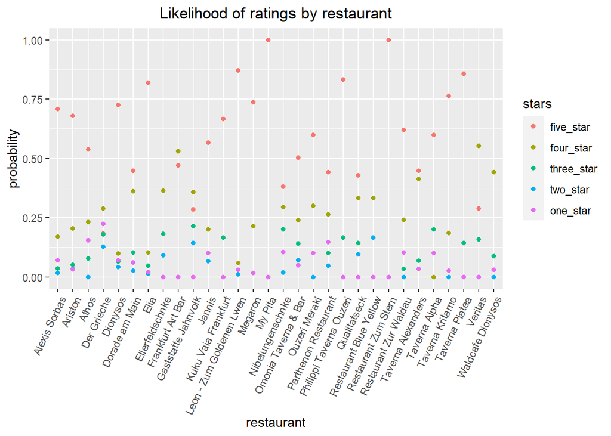

There are a few restaurants with fairly unique rating pattern, such as My Pita or Zum Stern. They received only five star ratings, which stand out from the crowd. To investigate this further, we check how many ratings these restaurants received in total.

```r
ggplot(data = longProb)+
  geom_point(mapping=aes(x=names, y = value, color=stars))+
  theme(axis.text.x = element_text(angle = 65, vjust = 1, hjust=1))+
  ggtitle("Likelihood of ratings by restaurant")+
  theme(plot.title = element_text(hjust = 0.5))+
  xlab("restaurant")+
  ylab("probability")
```

```r
df%>%filter(name=="My Pita"|name=="Restaurant Zum Stern")
```

```
## # A tibble: 2 x 6
##   name                 five_star four_star three_star two_star one_star
##   <chr>                    <dbl>     <dbl>      <dbl>    <dbl>    <dbl>
## 1 Restaurant Zum Stern         3         0          0        0        0
## 2 My Pita                      2         0          0        0        0
```

```r
long <- melt(df, id.vars = c("name"), value = "val", variable = "stars")
head(long)
```

```
##                       name     stars value
## 1                     Elia five_star   280
## 2                  Ariston five_star   577
## 3 Leon - Zum Goldenen Lwen five_star    88
## 4            Alexis Sorbas five_star   163
## 5     Omonia Taverna & Bar five_star    93
## 6                 Dionysos five_star   124
```

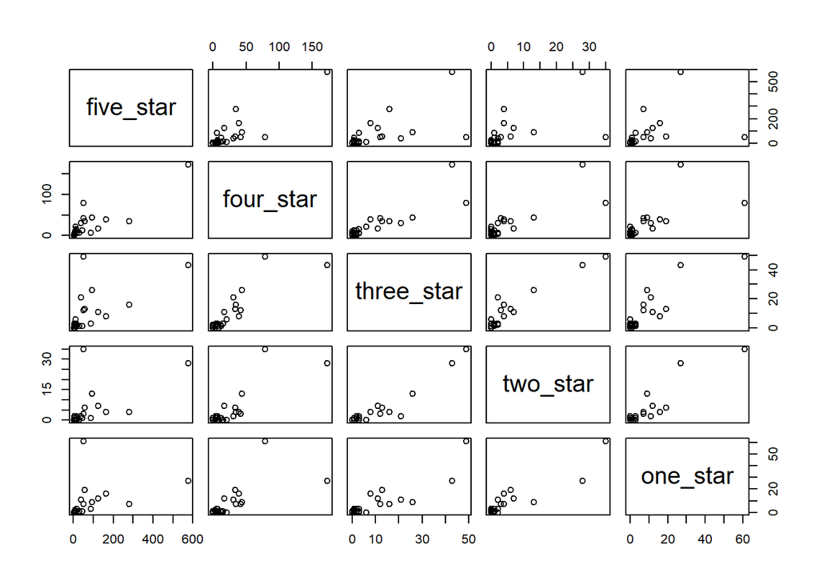

There seems to be a positive linear relation between three and four, as well as between one and two star ratings.

```r
plot(df[,2:6])
```

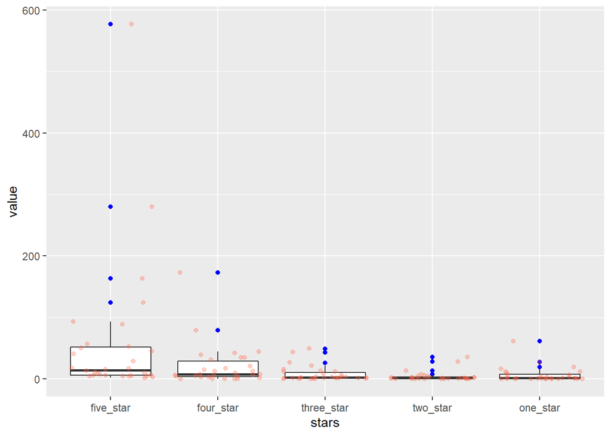

There are several outliers (marked blue) across all five categories.

```r
ggplot(data=long,aes(x=stars, y=value))+
  geom_boxplot(outlier.colour = 'blue')+
  geom_jitter(alpha = 0.3, color = "tomato")
```

We clean the data from the outliers using the 1.5 * IQR rule

```r
thresh_five <- IQR(df$five_star)*1.5
thresh_four <- IQR(df$four_star)*1.5
thresh_three <- IQR(df$three_star)*1.5
thresh_two <- IQR(df$two_star)*1.5
thresh_one <- IQR(df$one_star)*1.5
df_clean <- df%>%filter(df$five_star<thresh_five,df$four_star< thresh_four,df$three_star<thresh_three, df$two_star<thresh_two,df$one_star<thresh_one)
head(df_clean)
```

```
## # A tibble: 6 x 6
##   name               five_star four_star three_star two_star one_star
##   <chr>                  <dbl>     <dbl>      <dbl>    <dbl>    <dbl>
## 1 Taverna Kritamo           29         7          1        0        1
## 2 Megaron                   45        13          1        1        1
## 3 Waldcafe Dionysos         15        15          3        0        1
## 4 Veritas                   11        21          6        0        0
## 5 Frankfurt Art Bar          8         9          0        0        0
## 6 Taverna Alexanders        13        12          2        1        1
```

```r
long_clean <- melt(df_clean, id.vars = c("name"), value = "val", variable = "stars")
head(long_clean)
```

```
##                 name     stars value
## 1    Taverna Kritamo five_star    29
## 2            Megaron five_star    45
## 3  Waldcafe Dionysos five_star    15
## 4            Veritas five_star    11
## 5  Frankfurt Art Bar five_star     8
## 6 Taverna Alexanders five_star    13
```

Let’s fit a linear regression with the five star ratings as dependent variable, and the rest as predictors. Thus we can better understand how these impact the mean change on the five star reviews.

```r
lmRest <- lm(five_star~four_star+three_star+two_star+one_star, data=df_clean)
summary(lmRest)
```

```
##
## Call:
## lm(formula = five_star ~ four_star + three_star + two_star +
##     one_star, data = df_clean)
##
## Residuals:
##     Min      1Q  Median      3Q     Max
## -11.342  -3.417  -1.561   2.390  18.334
##
## Coefficients:
##             Estimate Std. Error t value Pr(>|t|)
## (Intercept)   5.0846     3.1272   1.626  0.12478
## four_star     1.5842     0.4445   3.564  0.00282 **
## three_star   -4.4126     1.9157  -2.303  0.03599 *
## two_star      2.7166     2.4568   1.106  0.28626
## one_star      2.6828     1.9167   1.400  0.18195
## ---
## Signif. codes:  0 '***' 0.001 '**' 0.01 '*' 0.05 '.' 0.1 ' ' 1
##
## Residual standard error: 7.81 on 15 degrees of freedom
## Multiple R-squared:  0.557,  Adjusted R-squared:  0.4388
## F-statistic: 4.714 on 4 and 15 DF,  p-value: 0.01154
```

There is evidence that 4 star reviews are associated with 5 star ones, having a p-value of 0.00282. Three star reviews are somewhat significant with a p-value of 0.03599. The rest of the predictors seem to be statistically insignificant. The RSE is relatively high with 7.81, and the multiple R-squared 0.557 indicates that these four input variables explain nearly 60% of the variance in five_star ratings. Besides, F-statistic: 4.714 and 0.01154 provides modest evidence against H_0, hence there is at least one input variable explaining the output.

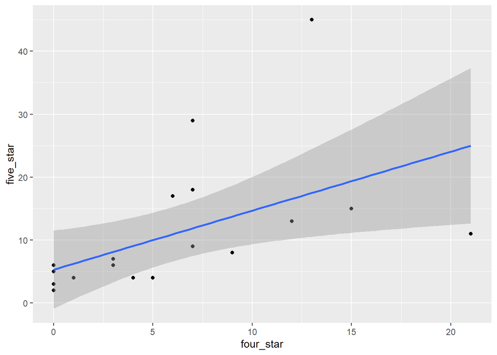

A 95% confidence interval around the regression. We likely have a high leverage point at x=21,restaurant Veritas and outliers y=29 Taverna Kritamo, y=45 Megaron.

```r
ggplot(df_clean, aes(x=four_star, y=five_star))+
  geom_point()+
  geom_smooth(method="lm")
```

We verify whether the relationship is linear by inspecting the residuals to identify non-linearity.

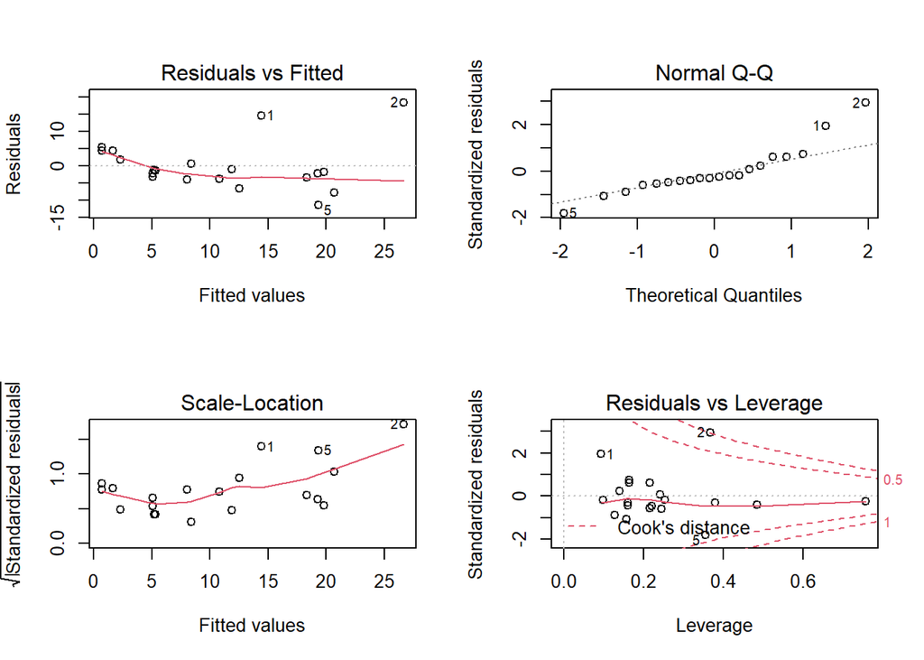

Although we have relaitvely few observations, we are likely to see some level of heteroscedasticity in our data, since the errors tend to increase as the fitted values increase. There is a slight pattern (red line) in the residuals too. Also, the plot of Residuals vs Leverage reveal the outlierpoints #1,2, and 5.

```r
par(mfrow=c(2,2))
plot(lmRest)
```

In line with the above, let’s try a polynomial fit

```r
lmPolyRest <- lm(five_star~ poly(four_star,3) + poly(three_star,3), data=df_clean)
summary(lmPolyRest)
```

```
##
## Call:
## lm(formula = five_star ~ poly(four_star, 3) + poly(three_star,
##     3), data = df_clean)
##
## Residuals:
##      Min       1Q   Median       3Q      Max
## -12.6277  -3.3660  -0.6254   3.0312  13.8470
##
## Coefficients:
##                      Estimate Std. Error t value Pr(>|t|)
## (Intercept)            10.800      1.598   6.760 1.34e-05 ***
## poly(four_star, 3)1    16.614     37.034   0.449   0.6611
## poly(four_star, 3)2   -30.283     37.504  -0.807   0.4339
## poly(four_star, 3)3   -20.052     23.732  -0.845   0.4134
## poly(three_star, 3)1    6.246     43.721   0.143   0.8886
## poly(three_star, 3)2   13.677     35.816   0.382   0.7087
## poly(three_star, 3)3   23.385     12.121   1.929   0.0758 .
## ---
## Signif. codes:  0 '***' 0.001 '**' 0.01 '*' 0.05 '.' 0.1 ' ' 1
##
## Residual standard error: 7.145 on 13 degrees of freedom
## Multiple R-squared:  0.6786, Adjusted R-squared:  0.5303
## F-statistic: 4.575 on 6 and 13 DF,  p-value: 0.01039
```

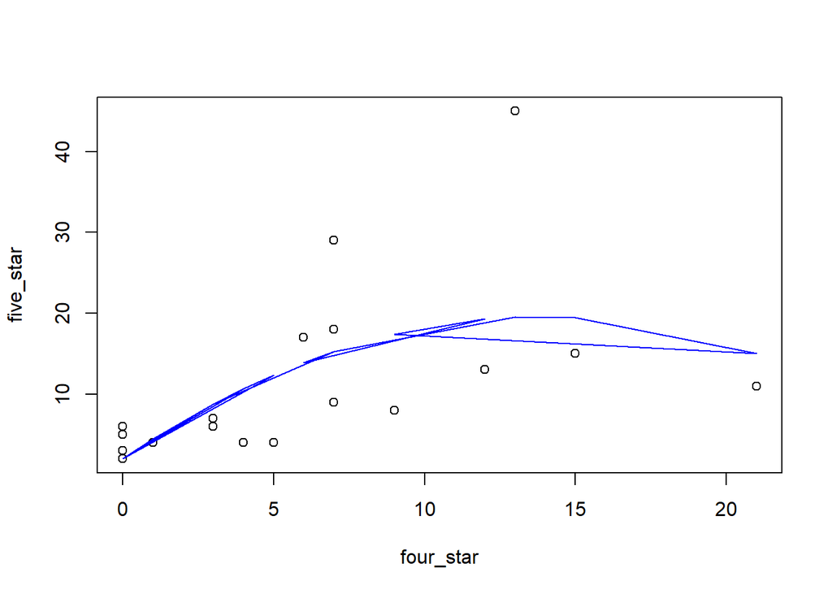

However, we see on the plot that the squared polynomial is clearly an overfit, which would then perform poorly on test data. Hence our best fit in terms of bias - variance is a straight line linear regression.

```r
lmPolyRest <- lm(five_star~ poly(four_star,2) , data=df_clean)
fivePredictions <-predict(lmPolyRest, type="response")
plot(five_star ~ four_star, data=df_clean)
lines(df_clean$four_star, y=fivePredictions, col="blue")
```

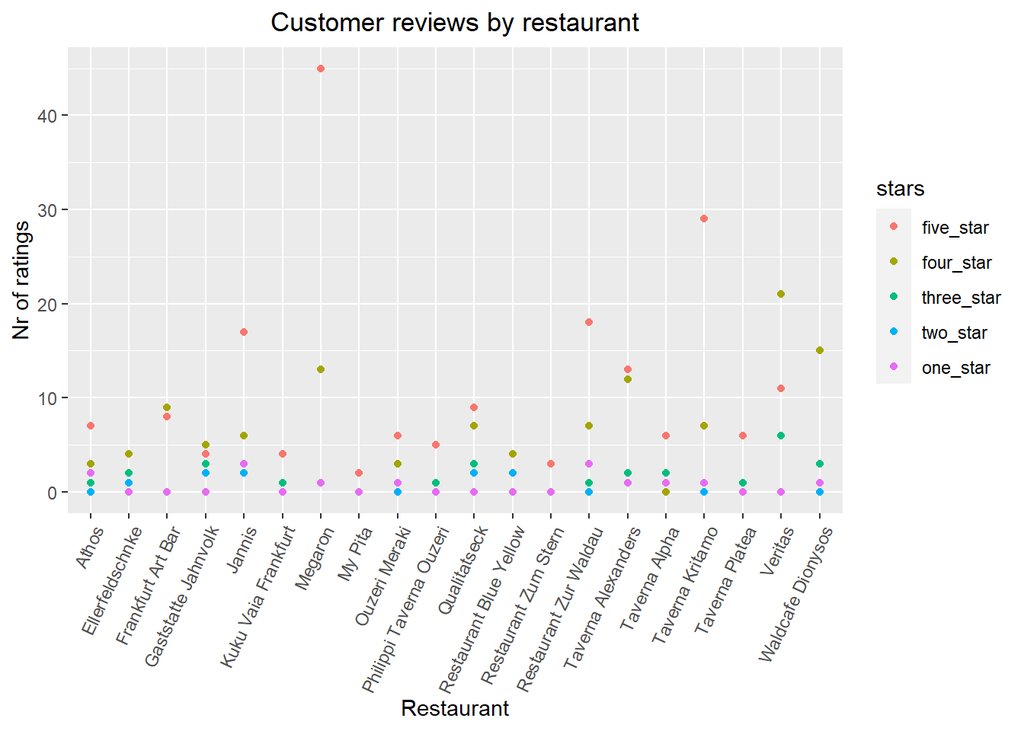

```r
ggplot(data = long_clean)+
  geom_point(mapping=aes(x=name, y = value, color=stars))+
  theme(axis.text.x = element_text(angle = 65, vjust = 1, hjust=1))+
  ggtitle("Customer reviews by restaurant")+
  theme(plot.title = element_text(hjust = 0.5))+
  xlab("Restaurant")+
  ylab("Nr of ratings")
```

The mean probabilities of each customer rating for one to five star:

```r
mean(probRating[,1])
```

```
## [1] 0.5868378
```

```r
mean(probRating[,2])
```

```
## [1] 0.2314122
```

```r
mean(probRating[,3])
```

```
## [1] 0.09558653
```

```r
mean(probRating[,4])
```

```
## [1] 0.03718618
```

```r
mean(probRating[,5])
```

```
## [1] 0.04897731
```

```r
summary(probDf)
```

```
##     names             five_star        four_star        three_star
##  Length:30          Min.   :0.1825   Min.   :0.0000   Min.   :0.00000
##  Class :character   1st Qu.:0.4413   1st Qu.:0.1184   1st Qu.:0.03456
##  Mode  :character   Median :0.5833   Median :0.2343   Median :0.08258
##                     Mean   :0.5868   Mean   :0.2314   Mean   :0.09559
##                     3rd Qu.:0.7346   3rd Qu.:0.3333   3rd Qu.:0.16447
##                     Max.   :1.0000   Max.   :0.5526   Max.   :0.21429
##     two_star          one_star
##  Min.   :0.00000   Min.   :0.00000
##  1st Qu.:0.00000   1st Qu.:0.00000
##  Median :0.01689   Median :0.02956
##  Mean   :0.03719   Mean   :0.04898
##  3rd Qu.:0.06163   3rd Qu.:0.09254
##  Max.   :0.16667   Max.   :0.22263
```

On average, a customer is most likely to give a 5-star- rating to a Greek restaurant with probability 0.5868378. At the same time, the least likely rating is a 2-star-review with 0.03718618.

Calculating the expected values:

```r
expected <- outer(rowSums(mat), colSums(mat), "*") / sum(mat)
head(expected)
```

```
##      five_star four_star three_star  two_star  one_star
## [1,] 205.76763  72.96473  27.672199 13.599585 21.995851
## [2,] 510.20747 180.91840  68.614108 33.720609 54.539419
## [3,]  60.76763  21.54806   8.172199  4.016252  6.495851
## [4,] 138.38174  49.06985  18.609959  9.145920 14.792531
## [5,] 111.30705  39.46923  14.968880  7.356501 11.898340
## [6,] 102.88382  36.48237  13.836100  6.799793 10.997925
```

Computing the test statistic:

```r
t <- sum((mat- expected)^2 / expected)
t
```

```
## [1] 666.8483
```

We obtained a test statistics of 666.8483, which is a large value. This is a sure inidcator for an extremely small p-value.

Despite the large t, we now go ahead calculate our p-value with chi-squared distribution, which is virtually zero:

```r
degrees <- (nrow(mat)-1) * (ncol(mat)-1)
degrees
```

```
## [1] 116
```

```r
1-pchisq(t, degrees)
```

```
## [1] 0
```

```r
chisq.test(mat, simulate.p.value = TRUE)
```

```
##
##  Pearson's Chi-squared test with simulated p-value (based on 2000
##  replicates)
##
## data:  mat
## X-squared = 666.85, df = NA, p-value = 0.0004998
```

Our p-value is 0.0004998, which is a very strong evidence against $H_{0}$.

Hence we have very convincing evidence against H_0: the probability of getting a certain rating differs between restaurants. An extremely small p-value is a surefire indicator that such differences in reviews don’t occur by random chance only.  
This clearly means some restaurants are more likely to be rated higher than other ones. As a conclusion we can say that the difference in rankings is meaningful, and customer ratings are an indicator for that.